# Global Ecommerce Sales

```python
import pandas as pd
import seaborn as sns
import matplotlib.pyplot as plt
import plotly.express as px
from IPython.display import HTML
import pyodbc
from sqlalchemy import create_engine
from urllib.parse import quote_plus
import os
```

```python
import kagglehub

# Download latest version
path = kagglehub.dataset_download("muhammadaammartufail/global-e-commerce-sales-and-customer-data")

print("Path to dataset files:", path)
```

```
Path to dataset files: C:\Users\USER\.cache\kagglehub\datasets\muhammadaammartufail\global-e-commerce-sales-and-customer-data\versions\1
```

```python
print(os.listdir(path))
```

```
['global_ecommerce_sales.csv']
```

```python
df = pd.read_csv(os.path.join(path, "global_ecommerce_sales.csv"))
```

```python
df.head(7)
```

|  | Order_ID | Order_Date | Customer_Name | Customer_Segment | Country | Region | Product_Category | Product_Name | Quantity | Unit_Price | Discount_Percent | Total_Sales | Shipping_Cost | Profit | Payment_Method |
| --- | --- | --- | --- | --- | --- | --- | --- | --- | --- | --- | --- | --- | --- | --- | --- |
| 0 | ORD-11121 | 2023-01-02 | Karen Suzuki | Corporate | United States | North America | Technology | Wireless Bluetooth Headphones | 3 | 99.43 | 0 | 298.29 | 9.31 | 124.92 | Cash on Delivery |
| 1 | ORD-11244 | 2023-01-02 | John Johansson | Corporate | Spain | Europe | Technology | Mechanical Gaming Keyboard | 4 | 97.93 | 20 | 313.38 | 14.31 | 83.62 | Cash on Delivery |
| 2 | ORD-10325 | 2023-01-03 | Jessica Garcia | Consumer | Mexico | North America | Office Supplies | Binder Clips Assorted 48pc | 2 | 10.74 | 0 | 21.48 | 8.12 | 3.69 | Credit Card |
| 3 | ORD-10467 | 2023-01-03 | Clara Taylor | Corporate | Italy | Europe | Technology | Webcam HD 1080p | 2 | 61.86 | 15 | 105.16 | 10.79 | 26.32 | PayPal |
| 4 | ORD-11454 | 2023-01-05 | Felix Thomas | Consumer | Italy | Europe | Furniture | Standing Desk Converter | 4 | 330.67 | 20 | 1058.14 | 11.09 | 253.44 | Credit Card |
| 5 | ORD-11746 | 2023-01-05 | Fatima Suzuki | Consumer | Mexico | North America | Furniture | Bookshelf 5-Tier | 1 | 61.93 | 10 | 55.74 | 5.88 | 12.70 | PayPal |
| 6 | ORD-11162 | 2023-01-06 | Felix Rodriguez | Home Office | United States | North America | Office Supplies | Premium Notebook Set A5 | 2 | 15.03 | 5 | 28.56 | 6.59 | 8.44 | PayPal |

# CHECKING DATASET SHAPE

```python
df.shape
```

```
(2000, 15)
```

# CHECKING COLUMN NAMES

```python
df.columns
```

```
Index(['Order_ID', 'Order_Date', 'Customer_Name', 'Customer_Segment',
       'Country', 'Region', 'Product_Category', 'Product_Name', 'Quantity',
       'Unit_Price', 'Discount_Percent', 'Total_Sales', 'Shipping_Cost',
       'Profit', 'Payment_Method'],
      dtype='object')
```

# CHECKING NULL VALUES

```python
df.isnull().sum()
```

```
Order_ID            0
Order_Date          0
Customer_Name       0
Customer_Segment    0
Country             0
Region              0
Product_Category    0
Product_Name        0
Quantity            0
Unit_Price          0
Discount_Percent    0
Total_Sales         0
Shipping_Cost       0
Profit              0
Payment_Method      0
dtype: int64
```

# CHECKING DUPLICATES

```python
df.duplicated().sum()
```

```
np.int64(0)
```

# CHECKING NEGATIVE VALUES

```python
columns = ["Total_Sales", "Profit"]
for col in columns:print(col, (df[col] < 0).sum())
```

```
Total_Sales 0
Profit 272
```

# CHECKING DATA INCONSISTENCIES

```python
df.groupby("Order_ID")["Order_Date"].nunique().max()
```

```
1
```

```python
df.groupby("Order_ID")["Customer_Name"].nunique().max()
```

```
1
```

```python
df.groupby("Order_ID")["Region"].nunique().max()
```

```
1
```

# CHECKING TEXT FORMATTING

```python
columns = ["Customer_Name", "Customer_Segment", "Country", "Region", "Product_Category", "Product_Name", "Payment_Method"]
for col in columns:print(col, df[col].str.strip().ne(df[col]).sum())
```

```
Customer_Name 0
Customer_Segment 0
Country 0
Region 0
Product_Category 0
Product_Name 0
Payment_Method 0
```

## DATA CLEANING SUMMARY

- **NULL VALUES:** NONE
- **DUPLICATE RECORDS:** NONE
- **DATA INCONSISTENCIES:** NONE FOUND
- **NEGATIVE SALES VALUES:** NONE
- **NEGATIVE PROFIT VALUES:** 272 ROWS — RETAINED AS VALID BUSINESS DATA
- **TEXT FORMATTING ISSUES:** NONE FOUND

> **DATASET HAS BEEN CHECKED AND CLEANED AND IS READY TO BE IMPORTED INTO SQL SERVER FOR FURTHER ANALYSIS.**

```python
conn = pyodbc.connect(
"DRIVER={ODBC Driver 17 for SQL Server};"
"SERVER=DESKTOP-KRJR07A\SQLEXPRESS;"
"DATABASE=STORE_DATA;"
"Trusted_connection=yes;"
)
print("CONNECT")
```

```
CONNECT
```

```python
params = quote_plus(
    "DRIVER={ODBC Driver 17 for SQL Server};"
    r"SERVER=DESKTOP-KRJR07A\SQLEXPRESS;"
    "DATABASE=STORE_DATA;"
    "Trusted_Connection=yes;"
)

engine = create_engine(
    "mssql+pyodbc:///?odbc_connect=" + params
)
```

```python
df.to_sql("global_ecommerce_sales", engine, if_exists="replace", index=False)
```

```
54
```

```python
pd.read_sql("""
SELECT TOP 3*
FROM global_ecommerce_sales

""",engine)
```

|  | Order_ID | Order_Date | Customer_Name | Customer_Segment | Country | Region | Product_Category | Product_Name | Quantity | Unit_Price | Discount_Percent | Total_Sales | Shipping_Cost | Profit | Payment_Method |
| --- | --- | --- | --- | --- | --- | --- | --- | --- | --- | --- | --- | --- | --- | --- | --- |
| 0 | ORD-11121 | 2023-01-02 | Karen Suzuki | Corporate | United States | North America | Technology | Wireless Bluetooth Headphones | 3 | 99.43 | 0 | 298.29 | 9.31 | 124.92 | Cash on Delivery |
| 1 | ORD-11244 | 2023-01-02 | John Johansson | Corporate | Spain | Europe | Technology | Mechanical Gaming Keyboard | 4 | 97.93 | 20 | 313.38 | 14.31 | 83.62 | Cash on Delivery |
| 2 | ORD-10325 | 2023-01-03 | Jessica Garcia | Consumer | Mexico | North America | Office Supplies | Binder Clips Assorted 48pc | 2 | 10.74 | 0 | 21.48 | 8.12 | 3.69 | Credit Card |

# CREATING DAY_NAME, MONTH_NAME & PROFIT_MARGIN

```python
cursor = conn.cursor()
cursor.execute("""
ALTER TABLE global_ecommerce_sales
ADD DAY_NAME VARCHAR(20),
MONTH_NAME VARCHAR(20),
PROFIT_MARGIN DECIMAL(20, 2)


""")
conn.commit()
```

```python
cursor.execute("""
UPDATE global_ecommerce_sales
SET
    DAY_NAME = DATENAME(WEEKDAY, Order_Date),
    MONTH_NAME = DATENAME(MONTH, Order_Date),
    PROFIT_MARGIN = (Profit / NULLIF(Total_Sales, 0)) * 100
""")

conn.commit()
```

```python
pd.read_sql("""
SELECT TOP 7 Order_Date,
DAY_NAME,
MONTH_NAME,
Total_Sales,
Profit,
PROFIT_MARGIN
FROM global_ecommerce_sales
""", engine)
```

|  | Order_Date | DAY_NAME | MONTH_NAME | Total_Sales | Profit | PROFIT_MARGIN |
| --- | --- | --- | --- | --- | --- | --- |
| 0 | 2023-01-02 | Monday | January | 298.29 | 124.92 | 41.88 |
| 1 | 2023-01-02 | Monday | January | 313.38 | 83.62 | 26.68 |
| 2 | 2023-01-03 | Tuesday | January | 21.48 | 3.69 | 17.18 |
| 3 | 2023-01-03 | Tuesday | January | 105.16 | 26.32 | 25.03 |
| 4 | 2023-01-05 | Thursday | January | 1058.14 | 253.44 | 23.95 |
| 5 | 2023-01-05 | Thursday | January | 55.74 | 12.70 | 22.78 |
| 6 | 2023-01-06 | Friday | January | 28.56 | 8.44 | 29.55 |

# SALES_BEFORE_DISCOUNT | SALES_AFTER_DISCOUNT | DISCOUNT_GIVEN | TOTAL_PROFIT | PROFIT_MARGIN | GROSS_LOSS | TOTAL_ORDERS | TOTAL_CUSTOMERS

```python
pd.read_sql("""
SELECT SUM(Quantity * Unit_Price) AS SALES_BEFORE_DISCOUNT,
SUM(Total_Sales) AS SALES_AFTER_DISCOUNT,
SUM(Quantity * Unit_Price) - SUM(Total_Sales) AS DISCOUNT_GIVEN,
SUM(Profit) AS TOTAL_PROFIT,
ROUND(SUM(Profit) * 100.0 / SUM(Total_Sales), 2) AS PROFIT_MARGIN,
SUM(CASE WHEN Profit < 0 THEN Profit ELSE 0 END) AS GROSS_LOSS,
COUNT(DISTINCT Order_ID)      AS TOTAL_ORDERS,
COUNT(DISTINCT Customer_Name) AS TOTAL_CUSTOMERS
FROM global_ecommerce_sales;

""",engine)
```

|  | SALES_BEFORE_DISCOUNT | SALES_AFTER_DISCOUNT | DISCOUNT_GIVEN | TOTAL_PROFIT | PROFIT_MARGIN | GROSS_LOSS | TOTAL_ORDERS | TOTAL_CUSTOMERS |
| --- | --- | --- | --- | --- | --- | --- | --- | --- |
| 0 | 530470.81 | 484559.34 | 45911.47 | 158872.32 | 32.79 | -953.39 | 2000 | 1534 |

# DAILY SALES

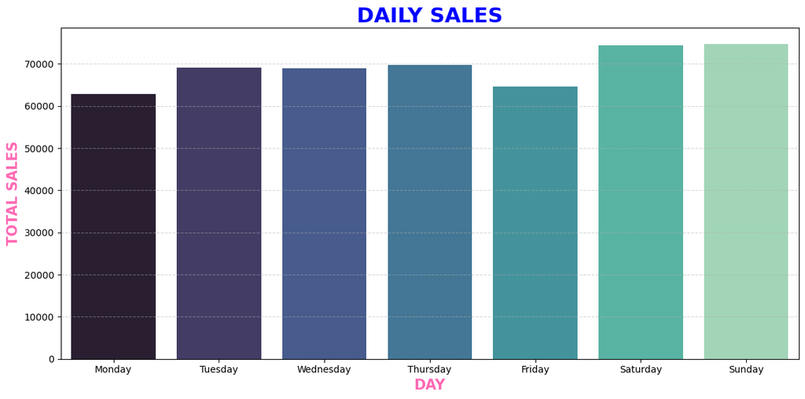

|  | DAY_NAME | TOTAL_SALES |
| --- | --- | --- |
| 0 | Monday | 62854.94 |
| 1 | Tuesday | 69075.22 |
| 2 | Wednesday | 69013.49 |
| 3 | Thursday | 69752.69 |
| 4 | Friday | 64637.76 |
| 5 | Saturday | 74438.71 |
| 6 | Sunday | 74786.53 |

```python
DAILY_SALES = pd.read_sql("""
SELECT DAY_NAME,
SUM(TOTAL_SALES) AS TOTAL_SALES
FROM global_ecommerce_sales
GROUP BY DAY_NAME
ORDER BY CASE DAY_NAME
WHEN 'Monday' THEN 1
WHEN 'Tuesday' THEN 2
WHEN 'Wednesday' THEN 3
WHEN 'Thursday' THEN 4
WHEN 'Friday' THEN 5
WHEN 'Saturday' THEN 6
WHEN 'Sunday' THEN 7
END;

""",engine)
plt.figure(figsize=(12, 6))
sns.barplot(data=DAILY_SALES, x="DAY_NAME", y="TOTAL_SALES", hue="DAY_NAME", palette="mako", legend=False)
plt.title("DAILY SALES", fontsize=22, fontweight="bold", color="blue")
plt.xlabel("DAY", fontsize=15, fontweight="bold", color="hotpink")
plt.ylabel("TOTAL SALES", fontsize=15, fontweight="bold", color="hotpink")
plt.grid(axis="y", linestyle="--", alpha=0.5)
plt.tight_layout()
plt.show()
DAILY_SALES
```

# MONTHLY SALES

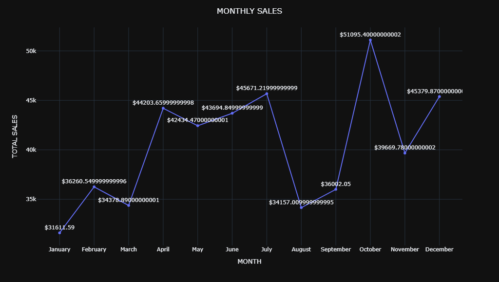

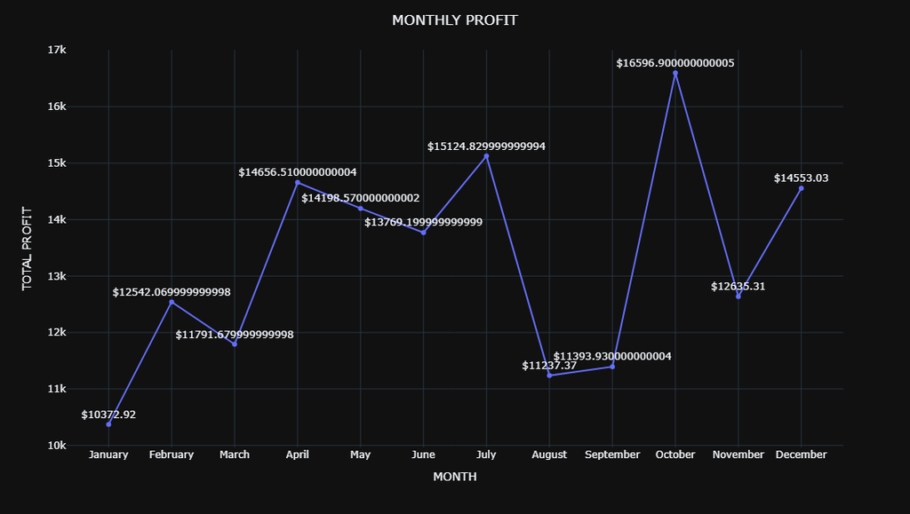

|  | MONTH_NAME | MONTH_NUM | TOTAL_SALES | TOTAL_PROFIT |
| --- | --- | --- | --- | --- |
| 0 | January | 1 | 31611.59 | 10372.92 |
| 1 | February | 2 | 36260.55 | 12542.07 |
| 2 | March | 3 | 34378.89 | 11791.68 |
| 3 | April | 4 | 44203.66 | 14656.51 |
| 4 | May | 5 | 42434.47 | 14198.57 |
| 5 | June | 6 | 43694.85 | 13769.20 |
| 6 | July | 7 | 45671.22 | 15124.83 |
| 7 | August | 8 | 34157.01 | 11237.37 |
| 8 | September | 9 | 36002.05 | 11393.93 |
| 9 | October | 10 | 51095.40 | 16596.90 |
| 10 | November | 11 | 39669.78 | 12635.31 |
| 11 | December | 12 | 45379.87 | 14553.03 |

```python
MONTH = pd.read_sql("""
SELECT MONTH_NAME, MONTH(Order_Date) AS MONTH_NUM,
SUM(Total_Sales) AS TOTAL_SALES,
SUM(Profit) AS TOTAL_PROFIT
FROM global_ecommerce_sales
GROUP BY MONTH_NAME, MONTH(Order_Date)
ORDER BY MONTH_NUM;
""", engine)

fig1 = px.line(MONTH, x="MONTH_NAME", y="TOTAL_SALES", text="TOTAL_SALES", markers=True)
fig1.update_traces(texttemplate="$%{text:,0f}", textposition="top center")
fig1.update_layout(title="MONTHLY SALES", title_x=0.5, xaxis_title="MONTH", yaxis_title="TOTAL SALES", height=600, width=1100, template="plotly_dark")
fig1.show()


fig2 = px.line(MONTH, x="MONTH_NAME", y="TOTAL_PROFIT", text="TOTAL_PROFIT", markers=True)
fig2.update_traces(texttemplate="$%{text:,0f}", textposition="top center")
fig2.update_layout(title="MONTHLY PROFIT", title_x=0.5, xaxis_title="MONTH", yaxis_title="TOTAL PROFIT", height=600, width=1100,
template="plotly_dark",)
fig2.show()
MONTH
```

# MONTHLY SALES IN EACH YEAR

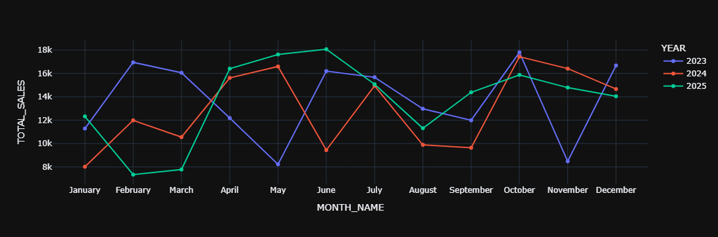

|  | YEAR |
| --- | --- |
| 0 | 2023 |
| 1 | 2024 |
| 2 | 2025 |

```python
MONTH_SALES = pd.read_sql("""
SELECT MONTH_NAME, MONTH(Order_Date) AS MONTH_NUM, YEAR(Order_Date) AS YEAR,
SUM(Total_Sales) AS TOTAL_SALES
FROM global_ecommerce_sales
GROUP BY MONTH_NAME, MONTH(Order_Date), YEAR(Order_Date)
ORDER BY YEAR,MONTH_NUM;

""",engine)

fig = px.line(MONTH_SALES, x="MONTH_NAME", y="TOTAL_SALES", color="YEAR", markers=True)
fig.update_layout(template="plotly_dark")
fig.show()
YEAR = pd.read_sql("""
SELECT DISTINCT YEAR(Order_Date) AS YEAR
FROM global_ecommerce_sales
ORDER BY YEAR;

""",engine)
YEAR
```

# GROWTH OR DECLINE BY MONTH & YEAR

```python
pd.read_sql("""
WITH MONTHLY_SALES AS (SELECT YEAR(Order_Date) AS YEAR, MONTH(Order_Date) AS MONTH, MONTH_NAME,
SUM(Total_Sales) AS TOTAL_SALES
FROM global_ecommerce_sales
GROUP BY YEAR(Order_Date), MONTH(Order_Date), MONTH_NAME),
WITH_PREV AS (SELECT*,
LAG(Total_Sales) OVER(ORDER BY YEAR, MONTH) AS PREVIOUS_MONTH_SALES FROM MONTHLY_SALES)
SELECT YEAR, MONTH, MONTH_NAME, TOTAL_SALES, PREVIOUS_MONTH_SALES,
TOTAL_SALES - PREVIOUS_MONTH_SALES AS GROWTH_SALES,
ROUND((TOTAL_SALES - PREVIOUS_MONTH_SALES)*100./NULLIF(PREVIOUS_MONTH_SALES, 0), 2) AS GROWTH_PERCENTAGE,
CASE  WHEN TOTAL_SALES > PREVIOUS_MONTH_SALES THEN 'Growth'
WHEN TOTAL_SALES < PREVIOUS_MONTH_SALES THEN 'Decline'
ELSE 'No Change' END PERFORMANCE
FROM WITH_PREV
ORDER BY YEAR, MONTH;



""",engine)
```

|  | YEAR | MONTH | MONTH_NAME | TOTAL_SALES | PREVIOUS_MONTH_SALES | GROWTH_SALES | GROWTH_PERCENTAGE | PERFORMANCE |
| --- | --- | --- | --- | --- | --- | --- | --- | --- |
| 0 | 2023 | 1 | January | 11275.20 | NaN | NaN | NaN | No Change |
| 1 | 2023 | 2 | February | 16943.67 | 11275.20 | 5668.47 | 50.27 | Growth |
| 2 | 2023 | 3 | March | 16056.45 | 16943.67 | -887.22 | -5.24 | Decline |
| 3 | 2023 | 4 | April | 12185.00 | 16056.45 | -3871.45 | -24.11 | Decline |
| 4 | 2023 | 5 | May | 8218.47 | 12185.00 | -3966.53 | -32.55 | Decline |
| 5 | 2023 | 6 | June | 16191.61 | 8218.47 | 7973.14 | 97.01 | Growth |
| 6 | 2023 | 7 | July | 15667.73 | 16191.61 | -523.88 | -3.24 | Decline |
| 7 | 2023 | 8 | August | 12971.07 | 15667.73 | -2696.66 | -17.21 | Decline |
| 8 | 2023 | 9 | September | 11989.72 | 12971.07 | -981.35 | -7.57 | Decline |
| 9 | 2023 | 10 | October | 17794.60 | 11989.72 | 5804.88 | 48.42 | Growth |
| 10 | 2023 | 11 | November | 8475.49 | 17794.60 | -9319.11 | -52.37 | Decline |
| 11 | 2023 | 12 | December | 16674.44 | 8475.49 | 8198.95 | 96.74 | Growth |
| 12 | 2024 | 1 | January | 8015.21 | 16674.44 | -8659.23 | -51.93 | Decline |
| 13 | 2024 | 2 | February | 11979.60 | 8015.21 | 3964.39 | 49.46 | Growth |
| 14 | 2024 | 3 | March | 10550.11 | 11979.60 | -1429.49 | -11.93 | Decline |
| 15 | 2024 | 4 | April | 15615.06 | 10550.11 | 5064.95 | 48.01 | Growth |
| 16 | 2024 | 5 | May | 16594.20 | 15615.06 | 979.14 | 6.27 | Growth |
| 17 | 2024 | 6 | June | 9435.15 | 16594.20 | -7159.05 | -43.14 | Decline |
| 18 | 2024 | 7 | July | 14937.53 | 9435.15 | 5502.38 | 58.32 | Growth |
| 19 | 2024 | 8 | August | 9883.83 | 14937.53 | -5053.70 | -33.83 | Decline |
| 20 | 2024 | 9 | September | 9636.38 | 9883.83 | -247.45 | -2.50 | Decline |
| 21 | 2024 | 10 | October | 17426.05 | 9636.38 | 7789.67 | 80.84 | Growth |
| 22 | 2024 | 11 | November | 16413.27 | 17426.05 | -1012.78 | -5.81 | Decline |
| 23 | 2024 | 12 | December | 14664.34 | 16413.27 | -1748.93 | -10.66 | Decline |
| 24 | 2025 | 1 | January | 12321.18 | 14664.34 | -2343.16 | -15.98 | Decline |
| 25 | 2025 | 2 | February | 7337.28 | 12321.18 | -4983.90 | -40.45 | Decline |
| 26 | 2025 | 3 | March | 7772.33 | 7337.28 | 435.05 | 5.93 | Growth |
| 27 | 2025 | 4 | April | 16403.60 | 7772.33 | 8631.27 | 111.05 | Growth |
| 28 | 2025 | 5 | May | 17621.80 | 16403.60 | 1218.20 | 7.43 | Growth |
| 29 | 2025 | 6 | June | 18068.09 | 17621.80 | 446.29 | 2.53 | Growth |
| 30 | 2025 | 7 | July | 15065.96 | 18068.09 | -3002.13 | -16.62 | Decline |
| 31 | 2025 | 8 | August | 11302.11 | 15065.96 | -3763.85 | -24.98 | Decline |
| 32 | 2025 | 9 | September | 14375.95 | 11302.11 | 3073.84 | 27.20 | Growth |
| 33 | 2025 | 10 | October | 15874.75 | 14375.95 | 1498.80 | 10.43 | Growth |
| 34 | 2025 | 11 | November | 14781.02 | 15874.75 | -1093.73 | -6.89 | Decline |
| 35 | 2025 | 12 | December | 14041.09 | 14781.02 | -739.93 | -5.01 | Decline |

# TOP TEN CUSTOMERS BY SALES & PROFIT

```python
pd.read_sql("""
SELECT TOP 10 Customer_Name,
SUM(Total_Sales) AS TOTAL_SALES,
SUM(Profit) AS TOTAL_PROFIT
FROM global_ecommerce_sales
GROUP BY Customer_Name
ORDER BY TOTAL_SALES DESC;
""",engine)
```

|  | Customer_Name | TOTAL_SALES | TOTAL_PROFIT |
| --- | --- | --- | --- |
| 0 | Priya Jackson | 3836.46 | 1390.64 |
| 1 | Hanna Jones | 3813.98 | 1370.08 |
| 2 | Sarah Chen | 3184.56 | 1153.99 |
| 3 | Li Laurent | 3007.62 | 1189.79 |
| 4 | Nadia Wang | 2958.97 | 1001.81 |
| 5 | Priya Oliveira | 2901.11 | 1054.26 |
| 6 | Felix Thompson | 2835.36 | 1115.05 |
| 7 | Linda Weber | 2762.40 | 657.86 |
| 8 | Karen Sato | 2738.18 | 884.82 |
| 9 | Lucas Nilsson | 2734.69 | 1016.19 |

# CUSTOMER_SEGMENT BY TOTAL SALES, TOTAL PROFIT, PROFIT_MARGIN & TOTAL QUANTITY

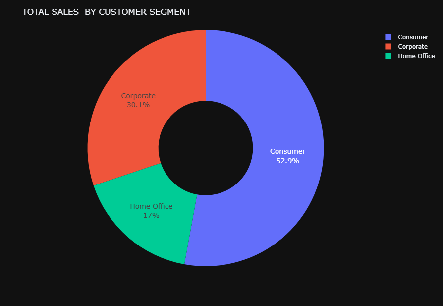

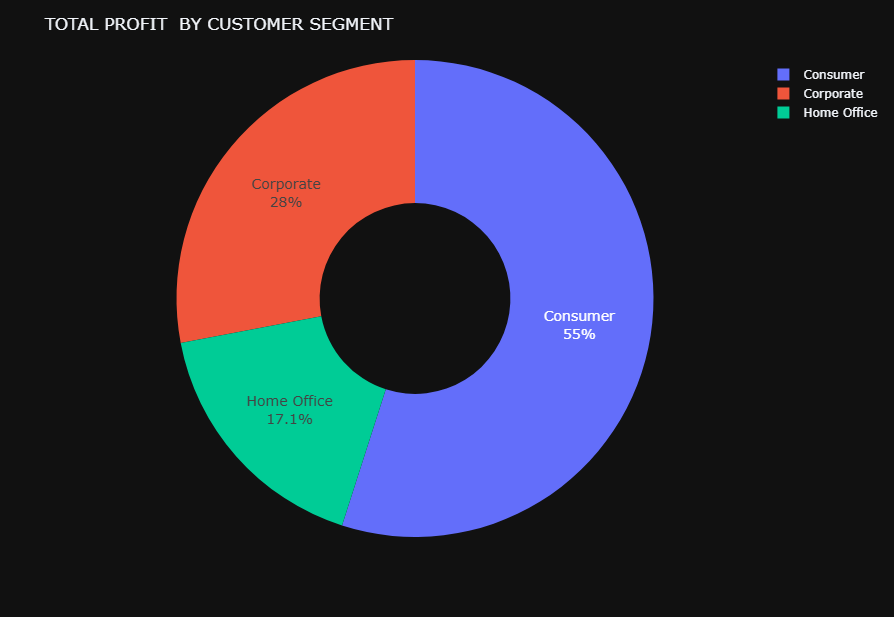

|  | Customer_Segment | TOTAL_SALES | TOTAL_PROFIT | TOTAL_QUANTITY | PROFIT_MARGIN |
| --- | --- | --- | --- | --- | --- |
| 0 | Consumer | 256287.74 | 87300.36 | 3602 | 34.06 |
| 1 | Corporate | 146050.39 | 44463.44 | 2195 | 30.44 |
| 2 | Home Office | 82221.21 | 27108.52 | 1318 | 32.97 |

```python
SEG_SALES_PROFIT = pd.read_sql("""
SELECT Customer_Segment,
SUM(Total_Sales) AS TOTAL_SALES,
SUM(Profit) AS TOTAL_PROFIT,
SUM(Quantity) AS TOTAL_QUANTITY,
ROUND(SUM(Profit) * 100.0/ NULLIF(SUM(Total_Sales), 0),2) AS PROFIT_MARGIN
FROM global_ecommerce_sales
GROUP BY Customer_Segment
ORDER BY TOTAL_SALES DESC;
""", engine)

fig1 = px.pie(SEG_SALES_PROFIT, names="Customer_Segment", values="TOTAL_SALES", hole=0.4)
fig1.update_traces(textinfo="percent+label", textposition="inside", textfont_size=14)
fig1.update_layout(template="plotly_dark", title="TOTAL SALES  BY CUSTOMER SEGMENT", height=600, width=900)
fig1.show()
fig2 = px.pie(SEG_SALES_PROFIT, names="Customer_Segment", values="TOTAL_PROFIT", hole=0.4)
fig2.update_traces(textinfo="percent+label", textposition="inside", textfont_size=14)
fig2.update_layout(template="plotly_dark", title="TOTAL PROFIT  BY CUSTOMER SEGMENT", height=600, width=900)
fig2.show()
SEG_SALES_PROFIT
```

# PARTITION BY CUSTOMER SEGMENT FOR EACH PRODUCT NAME & PRODUCT CATEGORY

```python
pd.read_sql("""
WITH RANK AS (SELECT Customer_Segment, Product_Category, Product_Name,
SUM(Total_Sales) AS TOTAL_SALES,
RANK() OVER(PARTITION BY Customer_Segment ORDER BY SUM(Total_Sales) DESC) AS RN
FROM global_ecommerce_sales
GROUP BY Customer_Segment, Product_Category, Product_Name)
SELECT Customer_Segment, Product_Category, Product_Name, TOTAL_SALES
FROM RANK
WHERE RN = 1
ORDER BY Customer_Segment;

""", engine)
```

|  | Customer_Segment | Product_Category | Product_Name | TOTAL_SALES |
| --- | --- | --- | --- | --- |
| 0 | Consumer | Furniture | Ergonomic Office Chair | 29972.23 |
| 1 | Corporate | Furniture | Corner L-Shaped Desk | 17826.21 |
| 2 | Home Office | Furniture | Standing Desk Converter | 8219.10 |

# TOTAL SALES, TOTAL PROFIT, TOTAL QUANTITY, PROFIT MARGIN BY COUNTRY

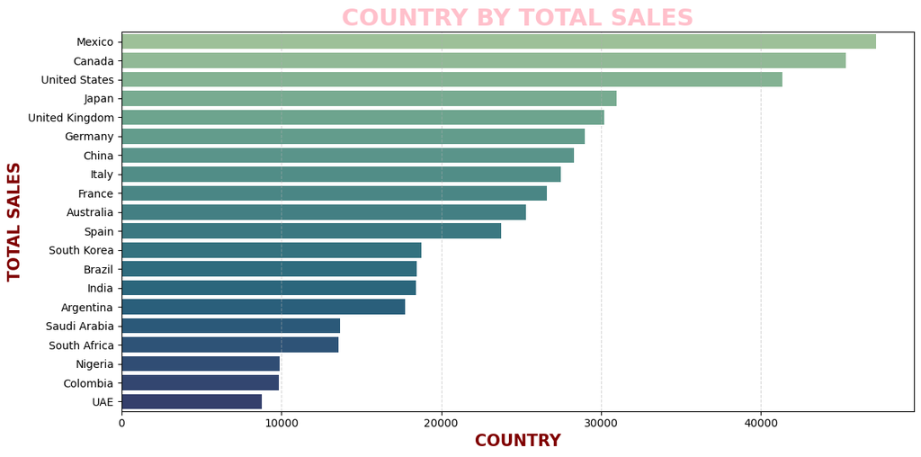

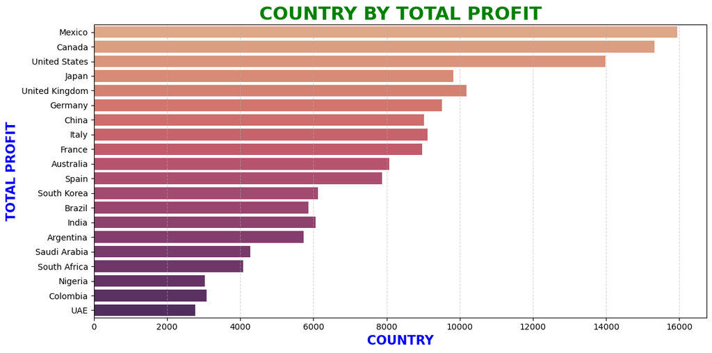

|  | Country | TOTAL_SALES | TOTAL_PROFIT | TOTAL_QUANTITY | PROFIT_MARGIN |
| --- | --- | --- | --- | --- | --- |
| 0 | Mexico | 47217.30 | 15949.44 | 712 | 33.78 |
| 1 | Canada | 45326.55 | 15320.95 | 620 | 33.80 |
| 2 | United States | 41332.53 | 13979.70 | 664 | 33.82 |
| 3 | Japan | 30950.19 | 9826.31 | 497 | 31.75 |
| 4 | United Kingdom | 30185.46 | 10185.32 | 374 | 33.74 |
| 5 | Germany | 28989.73 | 9518.07 | 399 | 32.83 |
| 6 | China | 28322.85 | 9028.07 | 409 | 31.88 |
| 7 | Italy | 27484.38 | 9125.06 | 378 | 33.20 |
| 8 | France | 26616.81 | 8973.46 | 393 | 33.71 |
| 9 | Australia | 25287.72 | 8072.37 | 382 | 31.92 |
| 10 | Spain | 23729.82 | 7870.25 | 278 | 33.17 |
| 11 | South Korea | 18745.21 | 6124.07 | 307 | 32.67 |
| 12 | Brazil | 18473.97 | 5869.63 | 231 | 31.77 |
| 13 | India | 18401.54 | 6065.79 | 314 | 32.96 |
| 14 | Argentina | 17717.00 | 5731.06 | 234 | 32.35 |
| 15 | Saudi Arabia | 13680.22 | 4276.09 | 191 | 31.26 |
| 16 | South Africa | 13564.80 | 4072.59 | 218 | 30.02 |
| 17 | Nigeria | 9899.91 | 3031.61 | 150 | 30.62 |
| 18 | Colombia | 9860.16 | 3080.29 | 193 | 31.24 |
| 19 | UAE | 8773.19 | 2772.19 | 171 | 31.60 |

```python
COUNTRY = pd.read_sql("""
SELECT Country,
SUM(Total_Sales) AS TOTAL_SALES,
SUM(Profit) AS TOTAL_PROFIT,
SUM(Quantity) AS TOTAL_QUANTITY,
ROUND(SUM(Profit) * 100.0/ NULLIF(SUM(Total_Sales), 0),2) AS PROFIT_MARGIN
FROM global_ecommerce_sales
GROUP BY Country
ORDER BY TOTAL_SALES DESC;
""", engine)
plt.figure(figsize=(12, 6))
sns.barplot(data=COUNTRY, x="TOTAL_SALES", y="Country", hue="Country", palette="crest", legend=False)
plt.title("COUNTRY BY TOTAL SALES", fontsize=22, fontweight="bold", color="pink")
plt.xlabel("COUNTRY", fontsize=15, fontweight="bold", color="maroon")
plt.ylabel("TOTAL SALES", fontsize=15, fontweight="bold", color="maroon")
plt.grid(axis="x", linestyle="--", alpha=0.5)
plt.tight_layout()
plt.show()
plt.figure(figsize=(12, 6))
sns.barplot(data=COUNTRY, x="TOTAL_PROFIT", y="Country", hue="Country", palette="flare", legend=False)
plt.title("COUNTRY BY TOTAL PROFIT", fontsize=22, fontweight="bold", color="green")
plt.xlabel("COUNTRY", fontsize=15, fontweight="bold", color="blue")
plt.ylabel("TOTAL PROFIT", fontsize=15, fontweight="bold", color="blue")
plt.grid(axis="x", linestyle="--", alpha=0.5)
plt.tight_layout()
plt.show()

COUNTRY
```

# TOTAL SALES, TOTAL PROFIT, TOTAL QUANTITY, PROFIT MARGIN BY REGION

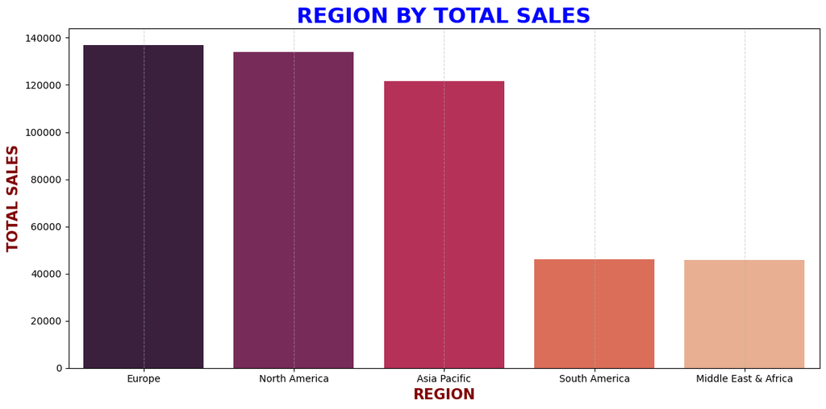

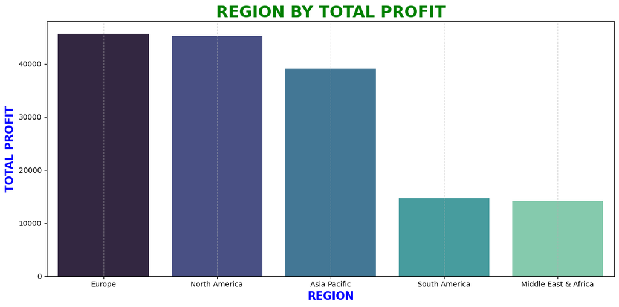

|  | Region | TOTAL_SALES | TOTAL_PROFIT | TOTAL_QUANTITY | PROFIT_MARGIN |
| --- | --- | --- | --- | --- | --- |
| 0 | Europe | 137006.20 | 45672.16 | 1822 | 33.34 |
| 1 | North America | 133876.38 | 45250.09 | 1996 | 33.80 |
| 2 | Asia Pacific | 121707.51 | 39116.61 | 1909 | 32.14 |
| 3 | South America | 46051.13 | 14680.98 | 658 | 31.88 |
| 4 | Middle East & Africa | 45918.12 | 14152.48 | 730 | 30.82 |

```python
REGION = pd.read_sql("""
SELECT Region,
SUM(Total_Sales) AS TOTAL_SALES,
SUM(Profit) AS TOTAL_PROFIT,
SUM(Quantity) AS TOTAL_QUANTITY,
ROUND(SUM(Profit) * 100.0/ NULLIF(SUM(Total_Sales), 0),2) AS PROFIT_MARGIN
FROM global_ecommerce_sales
GROUP BY Region
ORDER BY TOTAL_SALES DESC;
""", engine)
plt.figure(figsize=(12, 6))
sns.barplot(data=REGION, x="Region", y="TOTAL_SALES", hue="Region", palette="rocket", legend=False)
plt.title("REGION BY TOTAL SALES", fontsize=22, fontweight="bold", color="blue")
plt.xlabel("REGION", fontsize=15, fontweight="bold", color="maroon")
plt.ylabel("TOTAL SALES", fontsize=15, fontweight="bold", color="maroon")
plt.grid(axis="x", linestyle="--", alpha=0.5)
plt.tight_layout()
plt.show()
plt.figure(figsize=(12, 6))
sns.barplot(data=REGION, x="Region", y="TOTAL_PROFIT", hue="Region", palette="mako", legend=False)
plt.title("REGION BY TOTAL PROFIT", fontsize=22, fontweight="bold", color="green")
plt.xlabel("REGION", fontsize=15, fontweight="bold", color="blue")
plt.ylabel("TOTAL PROFIT", fontsize=15, fontweight="bold", color="blue")
plt.grid(axis="x", linestyle="--", alpha=0.5)
plt.tight_layout()
plt.show()
REGION
```

# TOTAL SALES, TOTAL PROFIT, TOTAL QUANTITY, PROFIT MARGIN BY PRODUCT CATEGORY

```python
pd.read_sql("""
SELECT Product_Category,
SUM(Total_Sales) AS TOTAL_SALES,
SUM(Profit) AS TOTAL_PROFIT,
SUM(Quantity) AS TOTAL_QUANTITY,
ROUND(SUM(Profit)*100.0/NULLIF(SUM(Total_Sales),0), 2) AS TOTAL_PROFIT_MARGIN
FROM global_ecommerce_sales
GROUP BY Product_Category
ORDER BY TOTAL_SALES DESC;

""",engine)
```

|  | Product_Category | TOTAL_SALES | TOTAL_PROFIT | TOTAL_QUANTITY | TOTAL_PROFIT_MARGIN |
| --- | --- | --- | --- | --- | --- |
| 0 | Furniture | 256274.68 | 81171.57 | 1806 | 31.67 |
| 1 | Technology | 139518.22 | 48268.65 | 2017 | 34.60 |
| 2 | Clothing & Accessories | 69375.63 | 26112.94 | 1551 | 37.64 |
| 3 | Office Supplies | 19390.81 | 3319.16 | 1741 | 17.12 |

# TOP PRODUCT IN EACH CATEGORY

```python
pd.read_sql("""
WITH PRODUCT_RANK AS (SELECT Product_Category, Product_Name,
SUM(Total_Sales) AS TOTAL_SALES,
RANK() OVER(PARTITION BY Product_Category ORDER BY SUM(Total_Sales) DESC) AS RN
FROM global_ecommerce_sales
GROUP BY Product_Category, Product_Name)
SELECT Product_Category, Product_Name, TOTAL_SALES
FROM PRODUCT_RANK
WHERE RN = 1
ORDER BY Product_Category;

""", engine)
```

|  | Product_Category | Product_Name | TOTAL_SALES |
| --- | --- | --- | --- |
| 0 | Clothing & Accessories | Business Casual Blazer | 14327.72 |
| 1 | Furniture | Standing Desk Converter | 46614.22 |
| 2 | Office Supplies | Tape Dispenser Heavy Duty | 3058.89 |
| 3 | Technology | Wireless Bluetooth Headphones | 28258.70 |

# TOTAL SALES, TOTAL PROFIT, TOTAL QUANTITY, PROFIT MARGIN BY PRODUCT NAME

```python
pd.read_sql("""
SELECT Product_Name,
SUM(Total_Sales) AS TOTAL_SALES,
SUM(Profit) AS TOTAL_PROFIT,
SUM(Quantity) AS TOTAL_QUANTITY,
ROUND(SUM(Profit)*100.0/NULLIF(SUM(Total_Sales),0), 2) AS TOTAL_PROFIT_MARGIN
FROM global_ecommerce_sales
GROUP BY Product_Name
ORDER BY TOTAL_SALES DESC;

""",engine)
```

|  | Product_Name | TOTAL_SALES | TOTAL_PROFIT | TOTAL_QUANTITY | TOTAL_PROFIT_MARGIN |
| --- | --- | --- | --- | --- | --- |
| 0 | Standing Desk Converter | 46614.22 | 14694.35 | 215 | 31.52 |
| 1 | Ergonomic Office Chair | 45405.15 | 15104.58 | 167 | 33.27 |
| 2 | Corner L-Shaped Desk | 41070.48 | 13663.00 | 146 | 33.27 |
| 3 | Mesh Back Task Chair | 38179.77 | 12820.11 | 213 | 33.58 |
| 4 | Wireless Bluetooth Headphones | 28258.70 | 10611.08 | 212 | 37.55 |
| 5 | Mechanical Gaming Keyboard | 24072.42 | 8381.19 | 227 | 34.82 |
| 6 | Filing Cabinet 3-Drawer | 23108.01 | 7041.80 | 170 | 30.47 |
| 7 | Folding Table Portable | 18663.13 | 5589.03 | 226 | 29.95 |
| 8 | Portable External SSD 1TB | 18065.30 | 6556.75 | 185 | 36.29 |
| 9 | Bookshelf 5-Tier | 17741.59 | 5490.57 | 154 | 30.95 |
| 10 | Noise Cancelling Earbuds | 16119.60 | 5973.01 | 138 | 37.05 |
| 11 | Business Casual Blazer | 14327.72 | 6004.33 | 160 | 41.91 |
| 12 | Floating Wall Shelves Set | 11767.30 | 3407.42 | 193 | 28.96 |
| 13 | Webcam HD 1080p | 11637.33 | 3910.34 | 211 | 33.60 |
| 14 | Travel Backpack 30L | 11204.23 | 4299.81 | 193 | 38.38 |
| 15 | Smart LED Desk Lamp | 10143.78 | 3289.21 | 222 | 32.43 |
| 16 | Wireless Ergonomic Mouse | 9995.39 | 3190.96 | 238 | 31.92 |
| 17 | Laptop Stand Adjustable | 9558.20 | 3174.20 | 207 | 33.21 |
| 18 | Polarized Sunglasses | 8454.43 | 3176.54 | 174 | 37.57 |
| 19 | Cotton Formal Shirt | 8306.97 | 3160.35 | 192 | 38.04 |
| 20 | Monitor Riser Wood | 8131.41 | 2010.94 | 174 | 24.73 |
| 21 | Canvas Messenger Bag | 6545.19 | 2455.64 | 144 | 37.52 |
| 22 | Tablet Stand Holder | 6061.77 | 1511.37 | 225 | 24.93 |
| 23 | Leather Wallet Minimalist | 5811.31 | 2181.81 | 153 | 37.54 |
| 24 | USB-C Hub Multiport Adapter | 5605.73 | 1670.54 | 152 | 29.80 |
| 25 | Desk Organizer Set | 5593.62 | 1349.77 | 148 | 24.13 |
| 26 | Leather Belt Classic | 5231.35 | 1836.80 | 165 | 35.11 |
| 27 | Wool Blend Scarf | 4256.55 | 1498.41 | 117 | 35.20 |
| 28 | Tape Dispenser Heavy Duty | 3058.89 | 856.52 | 210 | 28.00 |
| 29 | Sports Water Bottle 750ml | 2930.65 | 832.21 | 169 | 28.40 |
| 30 | Stapler Full-Size | 2622.15 | 544.94 | 211 | 20.78 |
| 31 | Premium Notebook Set A5 | 2536.17 | 665.31 | 166 | 26.23 |
| 32 | Desk Calendar 2025 | 2481.21 | 489.92 | 218 | 19.75 |
| 33 | Silk Tie Collection | 2307.23 | 667.04 | 84 | 28.91 |
| 34 | Whiteboard Markers Set 8 | 2090.67 | 311.95 | 177 | 14.92 |
| 35 | Binder Clips Assorted 48pc | 1924.59 | 214.49 | 194 | 11.14 |
| 36 | Ballpoint Pen Pack 12 | 1760.36 | 254.45 | 170 | 14.45 |
| 37 | Sticky Notes Multicolor 6-Pack | 1072.27 | 61.90 | 125 | 5.77 |
| 38 | Highlighters Neon Pack 6 | 942.61 | -0.37 | 118 | -0.04 |
| 39 | Paper Clips Box 500pc | 901.89 | -79.95 | 152 | -8.86 |

# PRODUCT NAME BY PROFIT LOSS

```python
pd.read_sql("""
SELECT Product_Name,
SUM(CASE WHEN Profit < 0 THEN Profit
ELSE 0 END) AS PROFIT_LOSS
FROM global_ecommerce_sales
GROUP BY Product_Name
HAVING SUM(Profit) < 0


""",engine)
```

|  | Product_Name | PROFIT_LOSS |
| --- | --- | --- |
| 0 | Highlighters Neon Pack 6 | -97.52 |
| 1 | Paper Clips Box 500pc | -171.73 |

# TOTAL SALES, TOTAL PROFIT, TOTAL QUANTITY, PROFIT MARGIN BY PAYMENT METHOD

```python
pd.read_sql("""
SELECT Payment_Method,
SUM(Total_Sales) AS TOTAL_SALES,
SUM(Profit) AS TOTAL_PROFIT,
SUM(Quantity) AS TOTAL_QUANTITY,
ROUND(SUM(Profit)*100.0/NULLIF(SUM(Total_Sales),0), 2) AS TOTAL_PROFIT_MARGIN
FROM global_ecommerce_sales
GROUP BY Payment_Method
ORDER BY TOTAL_SALES DESC;

""",engine)
```

|  | Payment_Method | TOTAL_SALES | TOTAL_PROFIT | TOTAL_QUANTITY | TOTAL_PROFIT_MARGIN |
| --- | --- | --- | --- | --- | --- |
| 0 | Credit Card | 192717.89 | 62323.24 | 2837 | 32.34 |
| 1 | PayPal | 143112.87 | 47288.80 | 2142 | 33.04 |
| 2 | Cash on Delivery | 77129.54 | 25704.89 | 1145 | 33.33 |
| 3 | Bank Transfer | 71599.04 | 23555.39 | 991 | 32.90 |

# TOTAL ORDERS, TOTAL CUSTOMERS, TOTAL SALES, TOTAL PROFIT, TOTAL QUANTITY, PROFIT MARGIN BY DISCOUNT PERCENT

```python
pd.read_sql("""
SELECT Discount_Percent,
COUNT(DISTINCT Order_ID) AS TOTAL_ORDERS,
COUNT(DISTINCT Customer_Name) AS TOTAL_CUSTOMERS,
SUM(Total_Sales) AS TOTAL_SALES,
SUM(Profit) AS TOTAL_PROFIT,
SUM(Quantity) AS TOTAL_QUANTITY,
ROUND(SUM(Profit) * 100.0 /NULLIF(SUM(Total_Sales), 0), 2) AS PROFIT_MARGIN
FROM global_ecommerce_sales
GROUP BY Discount_Percent
ORDER BY Discount_Percent;
""", engine)
```

|  | Discount_Percent | TOTAL_ORDERS | TOTAL_CUSTOMERS | TOTAL_SALES | TOTAL_PROFIT | TOTAL_QUANTITY | PROFIT_MARGIN |
| --- | --- | --- | --- | --- | --- | --- | --- |
| 0 | 0 | 503 | 467 | 130966.22 | 50705.28 | 1738 | 38.72 |
| 1 | 5 | 488 | 458 | 130452.23 | 46129.15 | 1806 | 35.36 |
| 2 | 10 | 443 | 412 | 103136.11 | 32932.51 | 1591 | 31.93 |
| 3 | 15 | 312 | 306 | 61074.44 | 16503.10 | 1047 | 27.02 |
| 4 | 20 | 169 | 164 | 40229.76 | 9305.38 | 634 | 23.13 |
| 5 | 25 | 67 | 67 | 13272.27 | 2568.58 | 221 | 19.35 |
| 6 | 30 | 18 | 18 | 5428.31 | 728.32 | 78 | 13.42 |

# TOTAL, AVERAGE, MIN, MAX SHIPPING COST

```python
pd.read_sql("""
SELECT
    SUM(Shipping_Cost) AS TOTAL_SHIPPING_COST,
    AVG(Shipping_Cost) AS AVG_SHIPPING_COST,
    MIN(Shipping_Cost) AS MIN_SHIPPING_COST,
    MAX(Shipping_Cost) AS MAX_SHIPPING_COST
FROM global_ecommerce_sales;
""", engine)
```

|  | TOTAL_SHIPPING_COST | AVG_SHIPPING_COST | MIN_SHIPPING_COST | MAX_SHIPPING_COST |
| --- | --- | --- | --- | --- |
| 0 | 25804.24 | 12.90212 | 5.52 | 40.44 |

```python
TOTAL_SALES = pd.read_sql("""
SELECT
    SUM(Total_Sales) AS TOTAL_SALES
FROM global_ecommerce_sales;
""", engine)

TOTAL_PROFIT = pd.read_sql("""
SELECT
    SUM(Profit) AS TOTAL_PROFIT
FROM global_ecommerce_sales;
""", engine)

PROFIT_MARGIN = pd.read_sql("""
SELECT
ROUND(SUM(Profit)*100.0/NULLIF(SUM(Total_Sales), 0), 2) AS PROFIT_MARGIN
FROM global_ecommerce_sales

""",engine)

TOTAL_PROFIT_LOSS = pd.read_sql("""
SELECT
    -SUM(CASE WHEN Profit < 0 THEN Profit ELSE 0 END) AS TOTAL_LOSS
FROM global_ecommerce_sales;
""", engine)

TOTAL_ORDERS = pd.read_sql("""
SELECT
    COUNT(DISTINCT Order_ID) AS TOTAL_ORDERS
FROM global_ecommerce_sales;
""", engine)

TOTAL_CUSTOMERS = pd.read_sql("""
SELECT
    COUNT(DISTINCT Customer_Name) AS TOTAL_CUSTOMERS
FROM global_ecommerce_sales;
""", engine)


HTML(f"""
<style>

body {{background: black; font-family: Arial, sans-serif;}}
.container {{display: flex; gap: 30px; padding: 30px; flex-wrap: wrap; justify-content: center;background:black;}}
.card {{width: 250px; padding: 30px; color: white; text-align: center; background: linear-gradient(150deg, #1a1a1a, #2e2e2e);
box-shadow: 4px 4px 10px blue; transition: 0.5s; border-radius: 20px;}}
.card:hover {{transform: translateY(-10px) scale(1.05); box-shadow: 0 20px 40px pink;}}
.value {{font-size: 30px; font-weight: bold;}}
.title {{font-size: 25px; font-weight: bold;}}

</style>

<div class="container">

<div class="card">
<h1 class="title">TOTAL SALES</h1>
<h2 class="value">{TOTAL_SALES.iloc[0,0]:,.2f}</h2>
</div>

<div class="card">
<h1 class="title">TOTAL PROFIT</h1>
<h2 class="value">{TOTAL_PROFIT.iloc[0,0]:,.2f}</h2>
</div>

<div class="card">
<h1 class="title">TOTAL LOSS</h1>
<h2 class="value">{TOTAL_PROFIT_LOSS.iloc[0,0]:,.2f}</h2>
</div>

<div class="card">
<h1 class="title">TOTAL ORDERS</h1>
<h2 class="value">{TOTAL_ORDERS.iloc[0,0]:,}</h2>
</div>

<div class="card">
<h1 class="title">TOTAL CUSTOMERS</h1>
<h2 class="value">{TOTAL_CUSTOMERS.iloc[0,0]:,}</h2>
</div>

<div class="card">
<h1 class="title">PROFIT MARGIN</h1>
<h2 class="value">{PROFIT_MARGIN.iloc[0,0]:,}%</h2>
</div>


</div>
""")
```

TOTAL SALES

484,559.34

TOTAL PROFIT

158,872.32

TOTAL LOSS

953.39

TOTAL ORDERS

2,000

TOTAL CUSTOMERS

1,534

PROFIT MARGIN

32.79%

## Conclusion

The analysis shows that the e-commerce business is performing profitably, generating **484,559.34 in sales, 158,872.32 in profit, and a 32.79% overall profit margin across 2,000 orders and 1,534 customers**. Consumer customers are the strongest segment, contributing the highest sales, profit, quantity, and profit margin. Furniture is the largest revenue-generating product category, while Clothing & Accessories delivers the highest profit margin.

The analysis also identifies several areas requiring management attention. Profitability decreases consistently as discount levels increase, with profit margin falling from **38.72% at no discount to 13.42% at a 30% discount**. Office Supplies has the weakest category margin at **17.12%**, while two products—**Paper Clips Box 500pc** and **Highlighters Neon Pack 6**—generate negative profit. Geographically, Europe generates the highest regional sales, while North America achieves the strongest regional profit margin. The monthly analysis also shows considerable fluctuations in performance, including periods of significant growth and decline.

Overall, the business has a healthy profit position, but profitability can potentially be improved through better discount control, optimization of low-margin products and categories, and closer monitoring of underperforming regions and products.

## Recommendations

1. **Control high discounts** Review discount strategies above 10–15%, as higher discount levels are associated with substantially lower profit margins. Discounts should be targeted toward products or customer segments where they can generate additional demand without significantly reducing profitability.
2. **Review Office Supplies profitability** Office Supplies has the lowest category margin at **17.12%**. Management should investigate supplier costs, pricing, discount levels, and shipping costs to identify opportunities for margin improvement.
3. **Investigate loss-making products** Review **Paper Clips Box 500pc** and **Highlighters Neon Pack 6** at the transaction level. Check purchase cost, selling price, discounts, and shipping expenses before deciding whether to reprice, discontinue, or bundle these products.
4. **Protect and expand the Consumer segment** Consumer customers generate the highest sales and profit and also have the strongest segment margin. Marketing and retention strategies should focus on increasing repeat purchases and customer lifetime value within this segment.
5. **Use high-margin products strategically** Clothing & Accessories has the highest category margin at **37.64%**. The business should consider promoting high-margin products and using them in bundles with lower-margin products.
6. **Improve Furniture profitability** Furniture generates the highest sales and profit but has a lower margin than Clothing & Accessories. The company should investigate product-level margins, sourcing costs, discounts, and shipping expenses within Furniture.
7. **Investigate regional profitability** Middle East & Africa has the lowest regional margin at **30.82%**. Further analysis should examine product mix, discounts, shipping costs, and customer segments within the region before making strategic changes.
8. **Use monthly performance monitoring** Continue monitoring month-over-month sales growth using `LAG()` and establish alerts for unusually large declines. This can help management react earlier to changes in demand.
9. **Optimize shipping costs** Analyze shipping cost by region, product category, and order value to identify areas where logistics expenses are reducing profitability.
10. **Build a recurring management dashboard** The final analysis could be converted into a Power BI dashboard showing sales, profit, margin, customer segments, regional performance, product performance, discount impact, and monthly growth so that these metrics can be monitored continuously.